# Exercise 12

Lili Benitez

2024-04-19

```
## # A tibble: 1,440 × 14
##    order        family      Genus species `mass(g)` `gestation(mo)` `newborn(g)`
##    <chr>        <chr>       <chr> <chr>       <dbl>           <dbl>        <dbl>
##  1 Artiodactyla Antilocapr… Anti… americ…    45375             8.13        3246.
##  2 Artiodactyla Bovidae     Addax nasoma…   182375             9.39        5480
##  3 Artiodactyla Bovidae     Aepy… melamp…    41480             6.35        5093
##  4 Artiodactyla Bovidae     Alce… busela…   150000             7.9        10167.
##  5 Artiodactyla Bovidae     Ammo… clarkei    28500             6.8           NA
##  6 Artiodactyla Bovidae     Ammo… lervia     55500             5.08        3810
##  7 Artiodactyla Bovidae     Anti… marsup…    30000             5.72        3910
##  8 Artiodactyla Bovidae     Anti… cervic…    37500             5.5         3846
##  9 Artiodactyla Bovidae     Bison bison     497667.            8.93       20000
## 10 Artiodactyla Bovidae     Bison bonasus   500000             9.14       23000.
## # ℹ 1,430 more rows
## # ℹ 7 more variables: `weaning(mo)` <dbl>, `wean mass(g)` <dbl>,
## #   `AFR(mo)` <dbl>, `max. life(mo)` <dbl>, `litter size` <dbl>,
## #   `litters/year` <dbl>, refs <dbl>
```

## Regression:

Regress the (now log transformed) age [gestation(mo), weaning(mo), AFR(mo) (age at first reproduction), and max. life(mo) (maximum lifespan)] and mass [newborn(g) and wean mass(g)] variables on (now log transformed) overall body mass(g) and add the residuals to the dataframe as new variables (relGest, relWean, relAFR, relLife, relNewbornMass, and relWeaningMass).

```r
m_gest<-lm(data=d_log, `mass(g)`~`gestation(mo)`, na.action = na.exclude)# not padding NAs
relGest<-resid(m_gest)
m_w<-lm(data=d_log, `mass(g)`~`weaning(mo)`, na.action=na.exclude)
relWean<-resid(m_w)
m_AFR<-lm(data=d_log,  `mass(g)`~`AFR(mo)`, na.action=na.exclude)
relAFR<-resid(m_AFR)
m_life<-lm(data=d_log,  `mass(g)`~`max. life(mo)`, na.action=na.exclude)
relLife<-resid(m_life)
m_new<-lm(data=d_log,  `mass(g)`~`newborn(g)`, na.action=na.exclude)
relNewbornMass<-resid(m_new)
m_w_m<-lm(data=d_log,  `mass(g)`~`wean mass(g)`, na.action=na.exclude)
relWeaningMass<-resid(m_w_m)

d_log<-d_log%>%
  mutate(relGest=relGest,
        relWean=relWean,
        relAFR=relAFR,
        relLife=relLife,
        relNewbornMass=relNewbornMass,
        relWeaningMass=relWeaningMass )
```

## Step 5

Plot residuals of max lifespan (relLife) in relation to Order. Which mammalian orders have the highest residual lifespan? Plot residuals of newborn mass (relNewbornMass) in relation to Order. Which mammalian orders have the have highest residual newborn mass? Plot residuals of weaning mass (relWeaningMass) in relation to Order. Which mammalian orders have the have highest relative weaning mass?

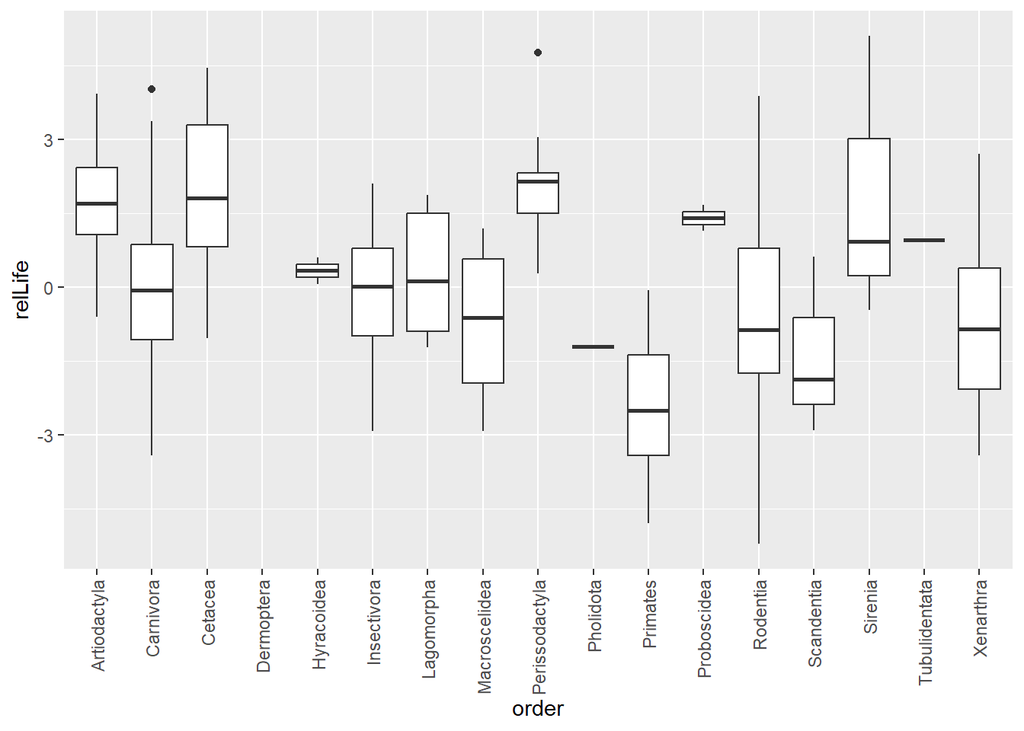

```r
ggplot(data=d_log, aes(x=order, y=relLife))+
  geom_boxplot()+
   theme(axis.text.x = element_text(angle = 90, vjust = 0.5, hjust=1))
```

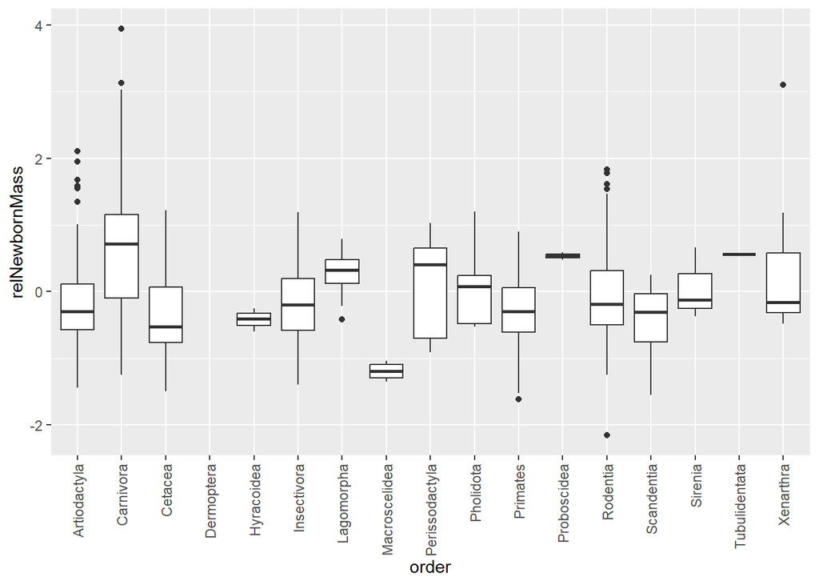

```r
ggplot(data=d_log, aes(x=order, y=relNewbornMass))+
  geom_boxplot()+
   theme(axis.text.x = element_text(angle = 90, vjust = 0.5, hjust=1))
```

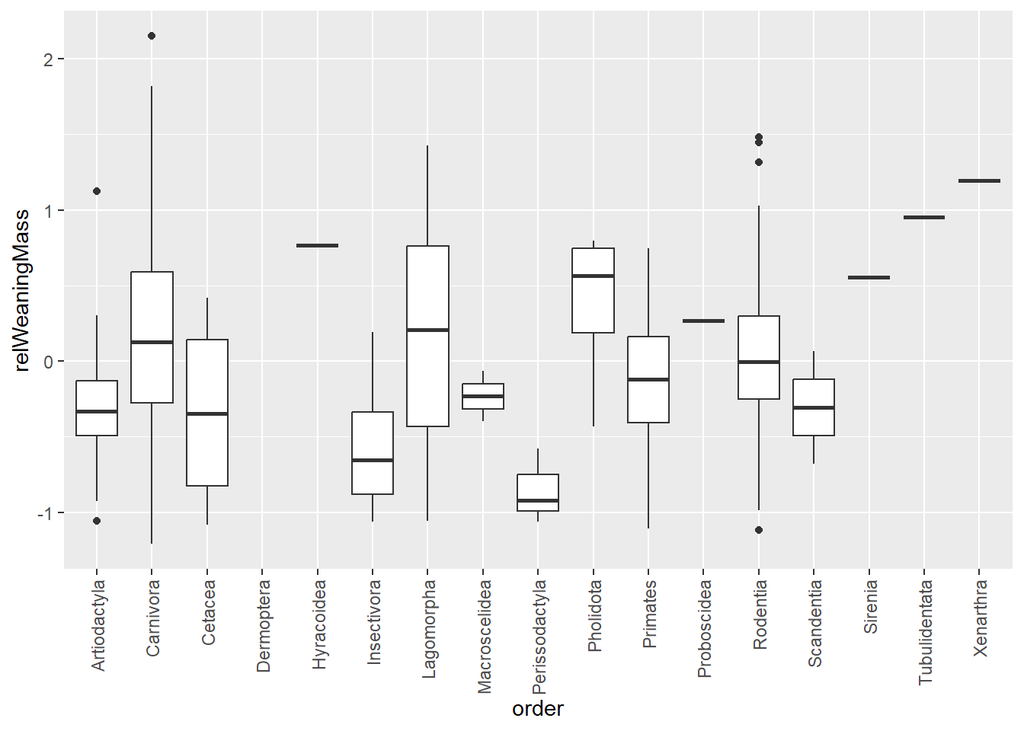

```r
ggplot(data=d_log, aes(x=order, y=relWeaningMass))+
  geom_boxplot()+
   theme(axis.text.x = element_text(angle = 90, vjust = 0.5, hjust=1))
```

For each of the two response variables, indicate what is the best model overall based on AICc and how many models have a delta AICc of 4 or less? What variables, if any, appear in all of this set of “top” models? Calculate and plot the model-averaged coefficients and their CIs across this set of top models.

```r
library(MASS)
library(AICcmodavg)
library(MuMIn)
D_log<-d_log%>%
  drop_na(`gestation(mo)`,`max. life(mo)`, `AFR(mo)`, `newborn(g)`, `weaning(mo)`, `wean mass(g)`, `litters/year`, `mass(g)`)

####life span model selection####
life_1<-lm(data=D_log, `max. life(mo)`~ `gestation(mo)`+ `newborn(g)`+`weaning(mo)`+`wean mass(g)`+`litters/year`+ `mass(g)`,  na.action=na.fail)
summary(life_1) #OHHH lol the model wasn't including total mass because I had a comma, newborn and wean mass not sig
```

```
##
## Call:
## lm(formula = `max. life(mo)` ~ `gestation(mo)` + `newborn(g)` +
##     `weaning(mo)` + `wean mass(g)` + `litters/year` + `mass(g)`,
##     data = D_log, na.action = na.fail)
##
## Residuals:
##      Min       1Q   Median       3Q      Max
## -1.42764 -0.24860 -0.02969  0.30037  1.01857
##
## Coefficients:
##                 Estimate Std. Error t value Pr(>|t|)
## (Intercept)      3.91047    0.17358  22.529  < 2e-16 ***
## `gestation(mo)`  0.36493    0.09838   3.709  0.00027 ***
## `newborn(g)`    -0.06342    0.05868  -1.081  0.28107
## `weaning(mo)`    0.12709    0.05389   2.358  0.01934 *
## `wean mass(g)`   0.02356    0.06922   0.340  0.73395
## `litters/year`  -0.23432    0.07917  -2.960  0.00346 **
## `mass(g)`        0.10853    0.05660   1.917  0.05662 .
## ---
## Signif. codes:  0 '***' 0.001 '**' 0.01 '*' 0.05 '.' 0.1 ' ' 1
##
## Residual standard error: 0.4442 on 199 degrees of freedom
## Multiple R-squared:  0.7689, Adjusted R-squared:  0.762
## F-statistic: 110.4 on 6 and 199 DF,  p-value: < 2.2e-16
```

```r
(s <- stepAIC(life_1, scope = . ~ ., direction = "both")) # - wean mass and - newborn(g) have better AIC
```

```
## Start:  AIC=-327.43
## `max. life(mo)` ~ `gestation(mo)` + `newborn(g)` + `weaning(mo)` +
##     `wean mass(g)` + `litters/year` + `mass(g)`
##
##                   Df Sum of Sq    RSS     AIC
## - `wean mass(g)`   1   0.02286 39.293 -329.31
## - `newborn(g)`     1   0.23054 39.500 -328.22
## <none>                         39.270 -327.43
## - `mass(g)`        1   0.72550 39.995 -325.66
## - `weaning(mo)`    1   1.09732 40.367 -323.75
## - `litters/year`   1   1.72842 40.998 -320.56
## - `gestation(mo)`  1   2.71500 41.985 -315.66
##
## Step:  AIC=-329.31
## `max. life(mo)` ~ `gestation(mo)` + `newborn(g)` + `weaning(mo)` +
##     `litters/year` + `mass(g)`
##
##                   Df Sum of Sq    RSS     AIC
## - `newborn(g)`     1   0.21387 39.507 -330.19
## <none>                         39.293 -329.31
## + `wean mass(g)`   1   0.02286 39.270 -327.43
## - `weaning(mo)`    1   1.15324 40.446 -325.35
## - `mass(g)`        1   1.63907 40.932 -322.89
## - `litters/year`   1   1.77294 41.066 -322.22
## - `gestation(mo)`  1   2.70723 42.000 -317.58
##
## Step:  AIC=-330.19
## `max. life(mo)` ~ `gestation(mo)` + `weaning(mo)` + `litters/year` +
##     `mass(g)`
##
##                   Df Sum of Sq    RSS     AIC
## <none>                         39.507 -330.19
## + `newborn(g)`     1    0.2139 39.293 -329.31
## + `wean mass(g)`   1    0.0062 39.500 -328.22
## - `weaning(mo)`    1    1.4531 40.960 -324.75
## - `litters/year`   1    2.1006 41.607 -321.52
## - `gestation(mo)`  1    3.2623 42.769 -315.85
## - `mass(g)`        1    3.6976 43.204 -313.76
```

```
##
## Call:
## lm(formula = `max. life(mo)` ~ `gestation(mo)` + `weaning(mo)` +
##     `litters/year` + `mass(g)`, data = D_log, na.action = na.fail)
##
## Coefficients:
##     (Intercept)  `gestation(mo)`    `weaning(mo)`   `litters/year`
##         4.03241          0.29528          0.14159         -0.25252
##       `mass(g)`
##         0.08226
```

```r
summary(s)
```

```
##
## Call:
## lm(formula = `max. life(mo)` ~ `gestation(mo)` + `weaning(mo)` +
##     `litters/year` + `mass(g)`, data = D_log, na.action = na.fail)
##
## Residuals:
##      Min       1Q   Median       3Q      Max
## -1.47943 -0.25454 -0.03637  0.30307  1.03470
##
## Coefficients:
##                 Estimate Std. Error t value Pr(>|t|)
## (Intercept)      4.03241    0.13276  30.374  < 2e-16 ***
## `gestation(mo)`  0.29528    0.07248   4.074 6.65e-05 ***
## `weaning(mo)`    0.14159    0.05207   2.719  0.00712 **
## `litters/year`  -0.25252    0.07724  -3.269  0.00127 **
## `mass(g)`        0.08226    0.01897   4.337 2.28e-05 ***
## ---
## Signif. codes:  0 '***' 0.001 '**' 0.01 '*' 0.05 '.' 0.1 ' ' 1
##
## Residual standard error: 0.4433 on 201 degrees of freedom
## Multiple R-squared:  0.7675, Adjusted R-squared:  0.7629
## F-statistic: 165.9 on 4 and 201 DF,  p-value: < 2.2e-16
```

```r
life_2<-lm(data=D_log, `max. life(mo)`~ `gestation(mo)`+ `newborn(g)`+`weaning(mo)`+`litters/year`+ `mass(g)`,  na.action=na.fail)
summary(life_2)# newborn not sig
```

```
##
## Call:
## lm(formula = `max. life(mo)` ~ `gestation(mo)` + `newborn(g)` +
##     `weaning(mo)` + `litters/year` + `mass(g)`, data = D_log,
##     na.action = na.fail)
##
## Residuals:
##      Min       1Q   Median       3Q      Max
## -1.42246 -0.24528 -0.02812  0.29558  1.02301
##
## Coefficients:
##                 Estimate Std. Error t value Pr(>|t|)
## (Intercept)      3.92020    0.17083  22.948  < 2e-16 ***
## `gestation(mo)`  0.36435    0.09815   3.712 0.000266 ***
## `newborn(g)`    -0.05423    0.05197  -1.043 0.298037
## `weaning(mo)`    0.12932    0.05337   2.423 0.016292 *
## `litters/year`  -0.23652    0.07873  -3.004 0.003005 **
## `mass(g)`        0.12140    0.04203   2.888 0.004299 **
## ---
## Signif. codes:  0 '***' 0.001 '**' 0.01 '*' 0.05 '.' 0.1 ' ' 1
##
## Residual standard error: 0.4432 on 200 degrees of freedom
## Multiple R-squared:  0.7688, Adjusted R-squared:  0.763
## F-statistic:   133 on 5 and 200 DF,  p-value: < 2.2e-16
```

```r
(s2 <- stepAIC(life_2, scope = . ~ ., direction = "both")) #  - newborn(g) has better AIC
```

```
## Start:  AIC=-329.31
## `max. life(mo)` ~ `gestation(mo)` + `newborn(g)` + `weaning(mo)` +
##     `litters/year` + `mass(g)`
##
##                   Df Sum of Sq    RSS     AIC
## - `newborn(g)`     1   0.21387 39.507 -330.19
## <none>                         39.293 -329.31
## - `weaning(mo)`    1   1.15324 40.446 -325.35
## - `mass(g)`        1   1.63907 40.932 -322.89
## - `litters/year`   1   1.77294 41.066 -322.22
## - `gestation(mo)`  1   2.70723 42.000 -317.58
##
## Step:  AIC=-330.19
## `max. life(mo)` ~ `gestation(mo)` + `weaning(mo)` + `litters/year` +
##     `mass(g)`
##
##                   Df Sum of Sq    RSS     AIC
## <none>                         39.507 -330.19
## + `newborn(g)`     1    0.2139 39.293 -329.31
## - `weaning(mo)`    1    1.4531 40.960 -324.75
## - `litters/year`   1    2.1006 41.607 -321.52
## - `gestation(mo)`  1    3.2623 42.769 -315.85
## - `mass(g)`        1    3.6976 43.204 -313.76
```

```
##
## Call:
## lm(formula = `max. life(mo)` ~ `gestation(mo)` + `weaning(mo)` +
##     `litters/year` + `mass(g)`, data = D_log, na.action = na.fail)
##
## Coefficients:
##     (Intercept)  `gestation(mo)`    `weaning(mo)`   `litters/year`
##         4.03241          0.29528          0.14159         -0.25252
##       `mass(g)`
##         0.08226
```

```r
life_3<-lm(data=D_log, `max. life(mo)`~ `gestation(mo)`+`weaning(mo)`+`litters/year`+ `mass(g)`,  na.action=na.fail)
summary(life_3) ##all sig
```

```
##
## Call:
## lm(formula = `max. life(mo)` ~ `gestation(mo)` + `weaning(mo)` +
##     `litters/year` + `mass(g)`, data = D_log, na.action = na.fail)
##
## Residuals:
##      Min       1Q   Median       3Q      Max
## -1.47943 -0.25454 -0.03637  0.30307  1.03470
##
## Coefficients:
##                 Estimate Std. Error t value Pr(>|t|)
## (Intercept)      4.03241    0.13276  30.374  < 2e-16 ***
## `gestation(mo)`  0.29528    0.07248   4.074 6.65e-05 ***
## `weaning(mo)`    0.14159    0.05207   2.719  0.00712 **
## `litters/year`  -0.25252    0.07724  -3.269  0.00127 **
## `mass(g)`        0.08226    0.01897   4.337 2.28e-05 ***
## ---
## Signif. codes:  0 '***' 0.001 '**' 0.01 '*' 0.05 '.' 0.1 ' ' 1
##
## Residual standard error: 0.4433 on 201 degrees of freedom
## Multiple R-squared:  0.7675, Adjusted R-squared:  0.7629
## F-statistic: 165.9 on 4 and 201 DF,  p-value: < 2.2e-16
```

```r
####Life span Model Averaging####
mods <- dredge(life_1, beta = "none", m.lim = c(0, 4))
```

```
## Fixed term is "(Intercept)"
```

```r
(mods.list <- get.models(mods, subset = TRUE))
```

[output not shown]

[output cut: 600 more lines]

[output not shown]

```r
coef(mods)
```

```
##    (Intercept) `gestation(mo)` `litters/year`  `mass(g)` `weaning(mo)`
## 40    4.032412       0.2952754     -0.2525193 0.08226121    0.14159144
## 52    4.132862       0.2847333     -0.2691681         NA    0.13506030
## 16    3.983147       0.4799683     -0.3292647 0.13268588            NA
## 8     4.170950       0.3876414     -0.3686750 0.07220230            NA
## 44    4.344534       0.2601086     -0.3087459         NA    0.14640907
## 24    4.167202       0.3922393     -0.3685168 0.08018049            NA
## 20    4.254018       0.3745994     -0.3786488         NA            NA
## 46    3.600221       0.3934726             NA 0.16149446    0.20727247
## 28    4.136892       0.4279325     -0.3497932         NA            NA
## 38    3.747149       0.2846067             NA 0.10240714    0.23573924
## 54    3.741842       0.2913915             NA 0.11424192    0.23571464
## 12    4.461923       0.3815220     -0.4227540         NA            NA
## 47    4.037970              NA     -0.2653854 0.06402910    0.22564564
## 50    3.850804       0.2706490             NA         NA    0.23532559
```

[output cut: 101 more lines]

```r
(mods.avg <- summary(model.avg(mods, subset = delta < 4, fit = TRUE))) #two of the models have delta AICc below 4
```

```
##
## Call:
## model.avg(object = get.models(object = mods, subset = delta <
##     4))
##
## Component model call:
## lm(formula = `max. life(mo)` ~ <2 unique rhs>, data = D_log, na.action
##      = na.fail)
##
## Component models:
##      df  logLik   AICc delta weight
## 1235  6 -122.21 256.83  0.00   0.81
## 1245  6 -123.63 259.69  2.85   0.19
##
## Term codes:
## `gestation(mo)`  `litters/year`       `mass(g)`  `wean mass(g)`   `weaning(mo)`
##               1               2               3               4               5
##
## Model-averaged coefficients:
## (full average)
##                 Estimate Std. Error Adjusted SE z value Pr(>|z|)
## (Intercept)      4.05185    0.13639     0.13715  29.544  < 2e-16 ***
## `gestation(mo)`  0.29324    0.07370     0.07415   3.955 7.66e-05 ***
## `litters/year`  -0.25574    0.07750     0.07797   3.280  0.00104 **
## `mass(g)`        0.06634    0.03669     0.03674   1.806  0.07094 .
## `weaning(mo)`    0.14033    0.05218     0.05249   2.673  0.00751 **
## `wean mass(g)`   0.01661    0.03522     0.03524   0.471  0.63732
##
## (conditional average)
##                 Estimate Std. Error Adjusted SE z value Pr(>|z|)
## (Intercept)      4.05185    0.13639     0.13715  29.544  < 2e-16 ***
## `gestation(mo)`  0.29324    0.07370     0.07415   3.955 7.66e-05 ***
## `litters/year`  -0.25574    0.07750     0.07797   3.280  0.00104 **
## `mass(g)`        0.08226    0.01897     0.01908   4.311 1.62e-05 ***
## `weaning(mo)`    0.14033    0.05218     0.05249   2.673  0.00751 **
## `wean mass(g)`   0.08586    0.02161     0.02174   3.949 7.83e-05 ***
## ---
## Signif. codes:  0 '***' 0.001 '**' 0.01 '*' 0.05 '.' 0.1 ' ' 1
```

```r
confint(mods.avg)
```

```
##                       2.5 %     97.5 %
## (Intercept)      3.78304344  4.3206545
## `gestation(mo)`  0.14790552  0.4385654
## `litters/year`  -0.40855582 -0.1029259
## `mass(g)`        0.04486373  0.1196587
## `weaning(mo)`    0.03744025  0.2432151
## `wean mass(g)`   0.04324855  0.1284642
```

```r
(mods.avg <- summary(model.avg(mods, subset = cumsum(weight) <= 0.95, fit = TRUE)))
```

```
##
## Call:
## model.avg(object = get.models(object = mods, subset = cumsum(weight) <=
##     0.95))
##
## Component model call:
## lm(formula = `max. life(mo)` ~ <6 unique rhs>, data = D_log, na.action
##      = na.fail)
##
## Component models:
##      df  logLik   AICc delta weight
## 1236  6 -122.21 256.83  0.00   0.69
## 1256  6 -123.63 259.69  2.85   0.17
## 1234  6 -124.63 261.68  4.84   0.06
## 123   5 -125.93 262.15  5.32   0.05
## 1246  6 -125.86 264.14  7.30   0.02
## 1235  6 -125.91 264.25  7.42   0.02
##
## Term codes:
## `gestation(mo)`  `litters/year`       `mass(g)`    `newborn(g)`  `wean mass(g)`
##               1               2               3               4               5
##   `weaning(mo)`
##               6
##
## Model-averaged coefficients:
## (full average)
##                  Estimate Std. Error Adjusted SE z value Pr(>|z|)
## (Intercept)      4.060585   0.146726    0.147450  27.539  < 2e-16 ***
## `gestation(mo)`  0.310327   0.089542    0.089917   3.451 0.000558 ***
## `litters/year`  -0.268562   0.082869    0.083292   3.224 0.001263 **
## `mass(g)`        0.069740   0.040889    0.040953   1.703 0.088579 .
## `weaning(mo)`    0.122680   0.067547    0.067760   1.811 0.070217 .
## `wean mass(g)`   0.014050   0.034172    0.034197   0.411 0.681175
## `newborn(g)`    -0.003598   0.026170    0.026210   0.137 0.890811
##
## (conditional average)
##                 Estimate Std. Error Adjusted SE z value Pr(>|z|)
## (Intercept)      4.06059    0.14673     0.14745  27.539  < 2e-16 ***
## `gestation(mo)`  0.31033    0.08954     0.08992   3.451 0.000558 ***
## `litters/year`  -0.26856    0.08287     0.08329   3.224 0.001263 **
## `mass(g)`        0.08541    0.02663     0.02675   3.193 0.001408 **
## `weaning(mo)`    0.14045    0.05222     0.05254   2.673 0.007512 **
## `wean mass(g)`   0.07700    0.03940     0.03952   1.949 0.051351 .
## `newborn(g)`    -0.04540    0.08212     0.08228   0.552 0.581133
## ---
## Signif. codes:  0 '***' 0.001 '**' 0.01 '*' 0.05 '.' 0.1 ' ' 1
```

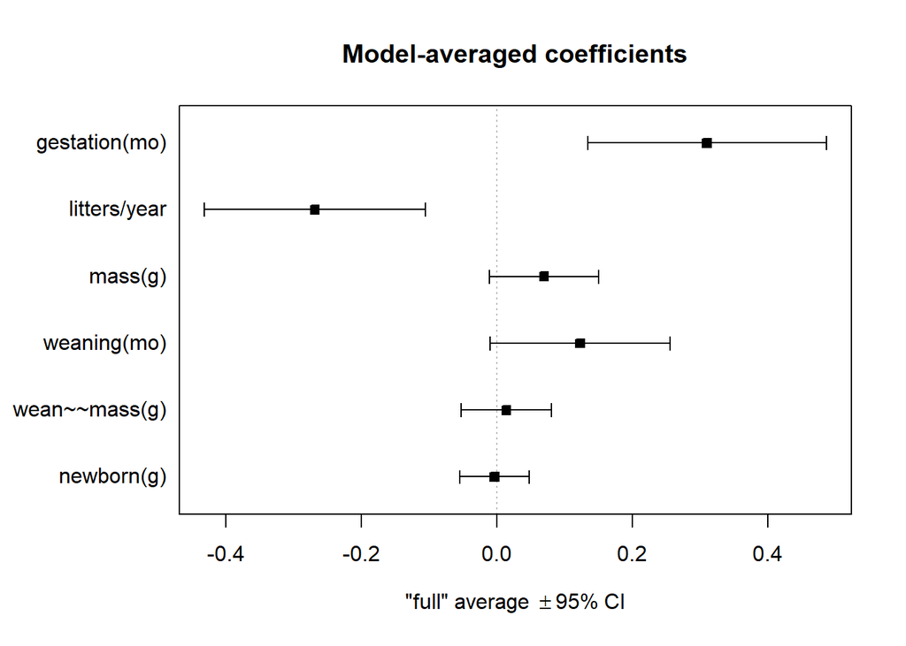

```r
plot(mods.avg , full = TRUE, intercept = FALSE)
```